# When Does Energy Abundance Increase State Power?

Stephen Weymouth

Dean’s Professor

2026-10-28

# Here is the Bakken oil field lighting up the North Dakota night in 2012. By 2025 the United States produced more crude oil than any country ever.

## Your IB Voice

Explain the reversal

In 2012 the Obama Admin persuaded China, India, Japan, and South Korea to buy less Iranian oil. In March 2026 the Trump Admin waived its own sanctions on Russian oil at sea. Why were sanctions on an oil exporter affordable in 2012 and costly in 2026?

**10 minutes** · Individual · Notes permitted

## Competing explanations

Why did the United States tighten sanctions on Iranian oil in 2012 but waive some of its sanctions on Russian oil in 2026?

In 2012 U.S. shale and extra Saudi oil could replace what Iran no longer sold.

Buyers cared enough about Iran’s nuclear program to pay a bit more.

U.S. pressure on banks and insurers left buyers little choice.

In 2026 the world had no spare oil, so any sanction raised prices everywhere.

# What brought about the shale revolution?

## Shale holds oil in rock

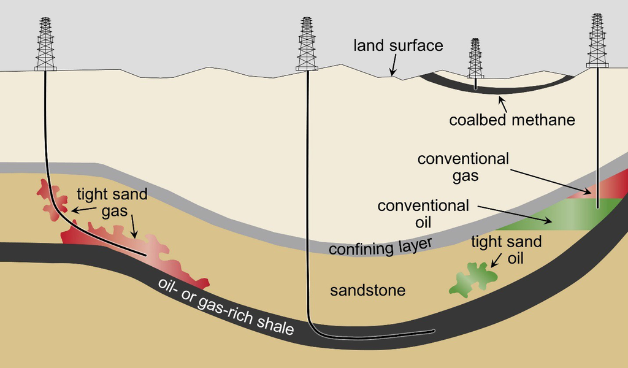

U.S. Environmental Protection Agency, [*Schematic cross-section of general types of oil and gas resources*](https://commons.wikimedia.org/wiki/File:Schematic_cross-section_of_general_types_of_oil_and_gas_resources_and_the_orientations_of_production_wells_used_in_hydraulic_fracturing.jpg), 2015 · Wikimedia Commons, public domain.

Much of the world’s oil formed in shale, a dense rock of hardened mud.

Oil that escaped rose into porous rock that ordinary wells could tap.

*Tight oil* (64% of U.S. crude production) is trapped in the shale or in other rock, and it flows only after that rock is cracked open.

# Pumps force in water and sand until the rock cracks, and the sand holds the cracks open.

## First a rig drills, then pumps crack the rock

[figure not shown]

[figure not shown]

Joshua Doubek, [*Helmerich & Payne Flex Rig drilling the Bakken*](https://commons.wikimedia.org/wiki/File:Helmerich_%26_Payne_Flex_Rig_drilling_the_Bakken.jpg) and [*Head of the frac pump*](https://commons.wikimedia.org/wiki/File:Head_of_the_frac_pump.JPG), 2011 · Wikimedia Commons, CC BY-SA 3.0.

The rig drills down and then sideways for up to two miles. Weeks later, a fleet of trucks pump water at the wellhead.

A Bakken well used about 8 million gallons of water in 2017 (about a dozen Olympic pools).

## Inside a fracked well

[video not shown]

SM Energy, [*Hydraulic Fracturing Process*](https://www.youtube.com/watch?v=T_yfPcX1gG4), animation, 2014, from 2:05 to 3:45.

The rock is cracked one section at a time, which is why fracking, not drilling, takes most of a well’s budget.

## A shale well costs a fraction of an offshore well

[figure not shown]

[figure not shown]

Costs per well fell by about a quarter from 2012 to 2015.

Map: PacWest Consulting Partners, North American shale basins and plays. Chart: U.S. Energy Information Administration, [*Trends in U.S. Oil and Natural Gas Upstream Costs*](https://www.eia.gov/analysis/studies/drilling/), 2016.

## U.S. oil output nearly tripled after 2008

[figure not shown]

U.S. Energy Information Administration, [*Monthly Energy Review*](https://www.eia.gov/totalenergy/data/monthly/), 2026, Table 3.1: crude oil production.

U.S. output, falling since 1985, turned up in 2009.

O’Sullivan’s *energy abundance* is the new supply of oil and gas from shale that made the United States a leading producer again.

# What does oil abundance add to U.S. power?

## Shale helped the local economy

O’Sullivan: military power rests on a strong economy.

One estimate credits shale with about 40 percent of all U.S. economic growth from 2008 to 2013.

[figure not shown]

U.S. Bureau of Economic Analysis, real GDP by state and for the United States, via [FRED](https://fred.stlouisfed.org/series/NDRGSP), 2026.

## Oil and gas jobs grew while the economy lost jobs

[figure not shown]

U.S. Bureau of Labor Statistics, *Current Employment Statistics*, via [FRED](https://fred.stlouisfed.org/series/CES1021100001), 2026: oil and gas extraction and support activities, and all nonfarm jobs.

Moody’s Analytics estimated that the boom created over a million jobs, including the jobs it supported. The 2008-2009 recession had cost two million factory jobs.

The jobs came when the economy needed them, but many left when oil prices fell in 2015.

## Cheap energy especially helpful for certain industries

[figure not shown]

U.S. Energy Information Administration, [*Manufacturing Energy Consumption Survey*](https://www.eia.gov/consumption/manufacturing/data/2018/), 2018, Table 6.1.

O’Sullivan names chemicals, metals, and paper as *energy-intensive*. In 2016 they were almost a third of U.S. manufacturing (more than the auto industry).

Cheap energy helps a paper mill far more than a carmaker.

# ExxonMobil and Saudi Arabia’s SABIC built a $10 billion plastics plant near Corpus Christi to use cheap U.S. gas. It opened in 2022 with 600 jobs paying about $90,000.

# Big River Steel began hiring at its $1 billion mill in Osceola, Arkansas, in 2016. Its first 425 jobs paid about $75,000, more than twice the state’s income per person.

## Cheap U.S. gas drew energy-intensive plants home

[figure not shown]

International Monetary Fund, *Primary Commodity Prices*, via [FRED](https://fred.stlouisfed.org/series/PNGASUSUSDM), 2026: natural gas, U.S. Henry Hub and EU; LNG, Asia.

Dow Chemical moved production to the Middle East in 2008, then spent $4 billion on plants in Texas and Louisiana.

In 2022 Russia cut its gas to Europe, and Europe and Asia paid more than five times the U.S. price.

## Oil has one world price, gas does not

[figure not shown]

International Monetary Fund, *Primary Commodity Prices*, via [FRED](https://fred.stlouisfed.org/series/PNGASEUUSDM), 2026, annual averages. Oil relative to West Texas Intermediate; gas relative to Henry Hub.

Tankers carry oil cheaply, so crude costs about the same everywhere.

To cross an ocean, gas is chilled to a liquid, which nearly doubles its cost before it sails.

Taxes make pump prices differ: 52 cents a gallon in the U.S., €3.80 in Germany.

# The US reliance on Gulf Oil

# On February 15, 2003, millions marched against the coming war in Iraq. Many said it was a war for oil.

## Who controls oil still matters to the United States

O’Sullivan argues U.S. wars aimed to keep adversaries from controlling oil, not to own it.

In 1991 the United States restored Kuwait without taking its oil fields.

[figure not shown]

O’Sullivan, *Windfall* (2017), ch. 5.

A *strategic* interest in oil is keeping adversaries from controlling it, while a *commercial* interest is owning or selling it.

## The U.S. military runs on oil

[figure not shown]

O’Sullivan, *Windfall* (2017), ch. 5.

The Pentagon uses more energy each day than all but 44 countries. One Navy destroyer burns about 1,000 gallons of fuel an hour.

By 2015 the Pentagon’s yearly fuel bill was $6 billion lower than in 2013, mostly because oil had become cheaper.

# One Army study counted a casualty for every 28 fuel convoys in Afghanistan. Cheaper oil does not make fuel safer to deliver.

## Is the U.S. still a guarantor of Gulf security?

Since 1945 the United States has protected Saudi Arabia, and later the other Gulf monarchies, in return for a steady flow of oil.

O’Sullivan predicted abundance would press the United States to do less. In October 2026 envoy Tom Barrack said it is no longer “the guarantor to the world.”

If the United States steps back, who protects the oil that sets the world price?

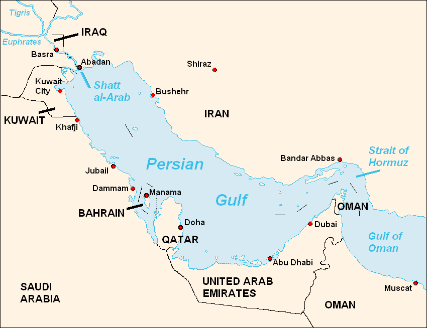

Hégésippe Cormier, [*Persian Gulf*](https://commons.wikimedia.org/wiki/File:Persian_Gulf_EN.PNG), 2007 · Wikimedia Commons, CC BY-SA 3.0.

# Why did sanctions on Iran work after 2012?

## How sanctions work

[figure not shown]

U.S. Department of the Treasury, [*The Treasury 2021 Sanctions Review*](https://home.treasury.gov/system/files/136/Treasury-2021-sanctions-review.pdf), 2021: Office of Foreign Assets Control designations, net of removals.

A *trade sanction* bans buying from or selling to a target. A *financial sanction* freezes the target’s U.S. assets and forbids Americans, including U.S. banks, to deal with it.

The chart counts the people, companies, ships, and aircraft named on Treasury sanctions lists.

*Economic coercion* is using trade and finance to make another state change its policy.

## Most sanctions fail to change a target’s policy

[figure not shown]

O’Sullivan, *Windfall* (2017), ch. 5, citing Hufbauer, Schott, Elliott, and Oegg, *Economic Sanctions Reconsidered*, and Robert Pape.

Two well-known studies disagree about how often sanctions work, but both find that most fail.

One reason, O’Sullivan argues, is that one country alone cannot cut a target off from the world economy.

Iran after 2012 is the exception the rest of this section explains.

## Stuart Levey took sanctions to the banks

In 2006 Levey, a Treasury official, read that a Swiss bank had cut off Iran.

He visited more than eighty countries to persuade banks to do the same.

*Secondary sanctions* penalize third parties, such as foreign banks, that do business with the target.

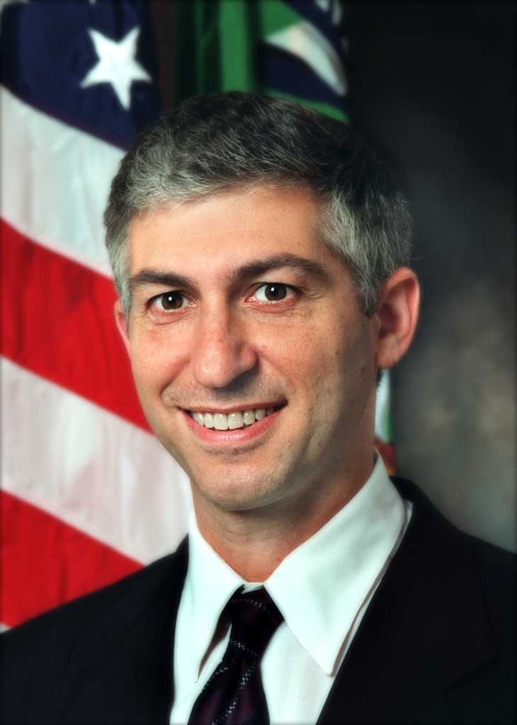

U.S. Department of the Treasury, [*Stuart Levey*](https://commons.wikimedia.org/wiki/File:Stuart_Levey.jpg) · Wikimedia Commons, public domain.

# European insurers covered about 95 percent of the world’s tankers. In July 2012 the EU banned them from insuring Iranian oil.

## U.S. output rose by more than Iran’s exports fell

China, India, Japan, and South Korea cut their Iranian purchases once they believed the oil could be replaced without a price spike.

Saudi Arabia also promised to pump more.

[figure not shown]

U.S. Energy Information Administration, [*Today in Energy*](https://www.eia.gov/todayinenergy/detail.php?id=14111), 2013, citing the IEA; EIA, *Monthly Energy Review*, Table 3.1.

Abundance made sanctions cheap for the countries asked to enforce them.

## Iran’s citizens felt the sanctions

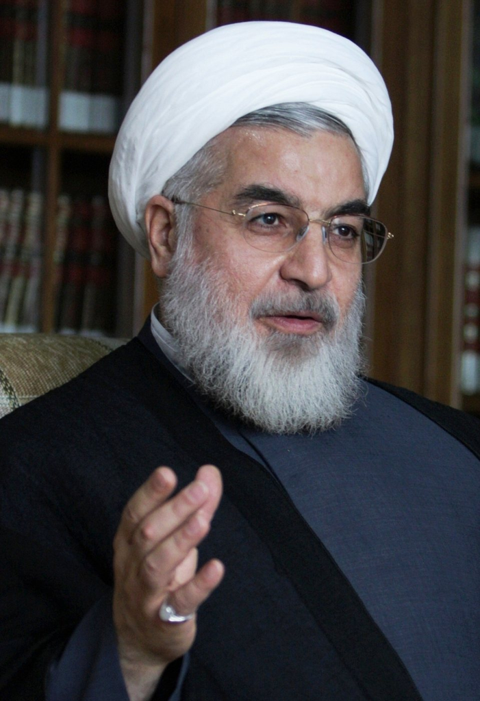

Mojtaba Salimi, [*Hassan Rouhani*](https://commons.wikimedia.org/wiki/File:Hassan_Rouhani_2.jpg), 2013 · Wikimedia Commons, CC BY-SA 3.0.

Iran’s economy shrank by a tenth in two years, and the rial lost half its value.

Hassan Rouhani became president in 2013 promising relief from sanctions.

O’Sullivan argues the pain pushed Iran’s leaders toward the 2015 nuclear deal.

## Japan joined the 2014 sanctions on Russia

Russia was Japan’s fourth-largest gas supplier, and Abe had met Putin five times since taking office.

Japan’s government joined anyway, partly because it expected U.S. liquefied gas to arrive soon.

Abundance helped by giving partners a substitute before they were asked to give up a supplier.

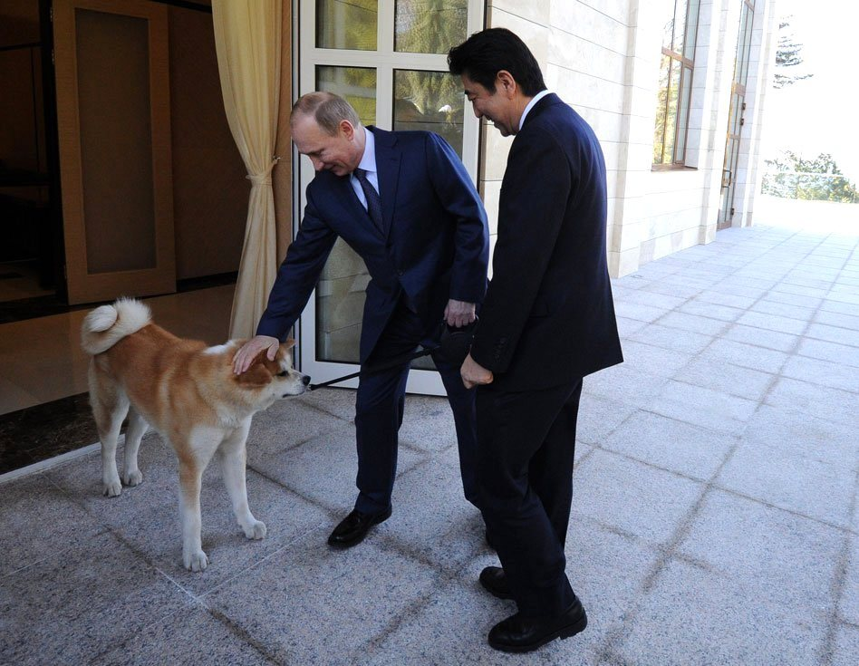

Presidential Press and Information Office, [*Vladimir Putin and Shinzo Abe*](https://commons.wikimedia.org/wiki/File:Vladimir_Putin_and_Shinzo_Abe_2014.jpeg), 2014 · Kremlin.ru via Wikimedia Commons, CC BY 4.0.

# What happens when oil is scarce again?

## Shale did not shield U.S. drivers in 2026

[figure not shown]

U.S. Energy Information Administration, [*Gasoline and Diesel Fuel Update*](https://www.eia.gov/petroleum/gasdiesel/), 2026: U.S. regular retail price, monthly average.

Oil trades in one world market, so a shortage anywhere raised the price U.S. drivers paid.

U.S. output was near a record, but the world had no oil to spare.

## The United States eased sanctions on Russian oil

[figure not shown]

News reports and IEA releases, February to October 2026; see notes.

On March 12 the Treasury let any buyer take Russian oil already at sea for 30 days.

Treasury Secretary Scott Bessent said the first waiver would “enable oil to keep flowing into the global market.”

With no spare oil, a sanction hurts the country imposing it too.

## Monday and today

In our last session, energy dependence meant buying oil from abroad. The United States now exports more than it imports, yet gasoline reached $4.48 in May. Is the United States still dependent, and on what?

## The U.S. reserve is back to its 1982 level

[figure not shown]

U.S. Energy Information Administration, [*Weekly Petroleum Status Report*](https://www.eia.gov/petroleum/supply/weekly/) and *Petroleum Supply Monthly*, 2026: crude oil in the Strategic Petroleum Reserve, end of month; last point the week ending October 23, 2026.

Built after 1973 to cover supply shortages, the reserve released about 250 million barrels in 2022 and 2023 and 130 million more since March 2026.

## Takeaways

When does energy abundance increase state power?

Shale made the United States a leading producer and strengthened its economy.

It did not end U.S. interest in who controls Gulf oil, because oil has one world price.

It made sanctions on Iran cheap, because buyers could replace Iranian oil without a price spike.

In 2026, with almost no spare oil, the United States eased sanctions on Russian oil instead.

Abundance added to U.S. power when the market had oil to spare.